# Lab2.1 - José Alberto: Temperatura JP x CG

```r
climas = read_csv(here::here("data/clima_cg_jp-semanal.csv"),
                  col_types = "cTdddddd")

glimpse(climas)
```

```
## Rows: 2,748
## Columns: 8
## $ cidade <chr> "Campina Grande", "Campina Grande", "Campina Grande", "Campina ~
## $ semana <dttm> 1992-12-27, 1993-01-03, 1993-01-10, 1993-01-31, 1993-02-07, 19~
## $ tmedia <dbl> 26.13333, 26.11905, 25.76667, 25.74000, 26.31429, 26.28571, 26.~
## $ tmax   <dbl> 30.4, 32.4, 32.2, 32.0, 32.7, 32.7, 32.3, 32.3, 32.1, 31.2, 32.~
## $ tmin   <dbl> 20.7, 19.3, 19.7, 19.9, 19.6, 20.0, 20.4, 21.2, 19.0, 19.0, 19.~
## $ chuva  <dbl> 0.0, 0.0, 0.0, 0.4, 0.3, 0.0, 4.9, 0.0, 0.0, 6.1, 0.4, 1.2, 0.0~
## $ mes    <dbl> 12, 1, 1, 1, 2, 2, 2, 2, 10, 11, 11, 11, 11, 12, 12, 12, 12, 1,~
## $ ano    <dbl> 1992, 1993, 1993, 1993, 1993, 1993, 1993, 1993, 1993, 1993, 199~
```

**ALUNO: JOSÉ ALBERTO SOUZA PAULINO**

**DISCIPLINA: FPCC II**

## **>> ATIVIDADE: LAB2.1**

### Q1: Qual a cidade é mais quente? Isso muda se considerarmos apenas o período de janeiro e fevereiro (pico do verão)?

De acordo com a temperatura médias observada entre os anos de 1993 e 2019, João Pessoa é predominantemente mais quente que Campina Grande. As médias de temperatura em Campina Grande raramente ultrapassam 27 graus, ao passo que a maior concentração de temperaturas de João Pessoa está acima dessa marca. A diferença de temperatura entre as cidades também se mantem entre os meses de Janeiro e fevereiro, que correspondem ao pico do verão.

Ademais, percebe-se que a distribuição das temperaturas médias possui variação menor em João Pessoa, principalmente no pico do verão. Nesse período, a variação em Campina Grande é de até 5 graus (~23º à ~28º).

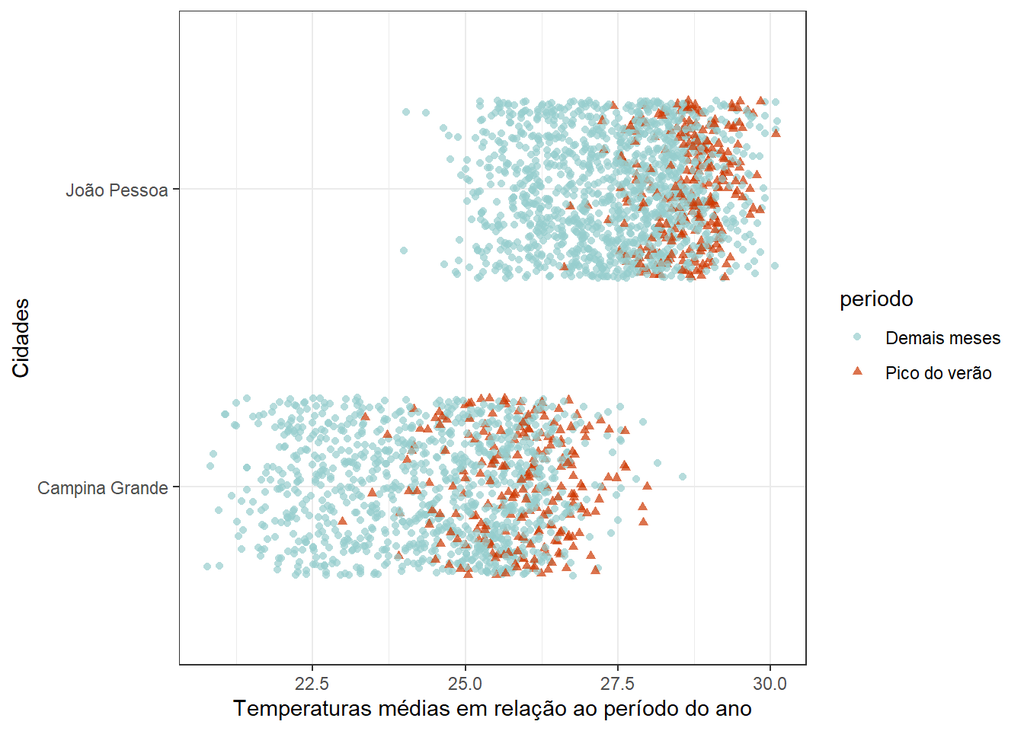

```r
climas_temp <- climas %>%
    mutate(periodo = if_else(mes <= 2, 'Pico do verão', 'Demais meses'))

climas_temp %>%
    ggplot(mapping = aes(x = tmedia, y = cidade, color = periodo, shape = periodo)) +
    #geom_point()+
    geom_jitter(height = .3, alpha = .7)+
    labs(x='Temperaturas médias em relação ao período do ano', y= "Cidades")+
    scale_color_manual(breaks = c("Demais meses", "Pico do verão"), values=c("paleturquoise3","orangered3"))
```

### Q2: Quais os meses mais quentes e mais frios? Como você descreveria a temperatura das festas juninas das cidades nos últimos anos?

No período de festas juninas, a média de temperatura em JP caiu gradativamente entre 2016 e 2018. Já na cidade de Campina grande, houve uma pequena variação entre o ano de 2016 e 2017, e a temperatura se manteve em variações em 2018.

[figure not shown]

```r
p1 <- climas_temp %>%
    group_by(mes)%>%
    filter(ano > 2017) %>%
    summarise(MediaTemper = mean(tmedia))%>%
    ggplot(mapping = aes(x = mes, y = MediaTemper)) +
    geom_bar(stat = "identity", fill='lightblue')+
    scale_x_continuous(breaks = 1:12, limits = c(0.5,12.5)) +
    scale_y_continuous(breaks = seq(0, 30, by = 3)) +
    labs(x='Meses do ano', y= "Média das Temperaturas")+
    ggtitle("Média das temperaturas mês a mês entre 1993 e 2019")

p2 <- climas_temp %>%
    filter(ano > 2015) %>%
    filter(mes == 6) %>%
    ggplot(mapping = aes(x = ano, y = tmedia)) +
        geom_bar(stat = "identity", aes(fill = cidade), position = "dodge")+
        scale_x_continuous(breaks = )+
        scale_y_continuous(breaks = seq(0, 30, by = 3)) +
        labs(x='Média das temperaturas por cidade', y= "Temperatura")+
        scale_color_manual(breaks = c("Campina Grande", "João Pessoa"),
                           values=c("paleturquoise3","orangered3"))+
        ggtitle("Média das temperaturas no mês de junho entre 2016 e 2018")

grid.arrange(p1, p2, nrow = 2)
```

### Q3: Quanto chove por semana em JP e CG? Descreva a distribuição do volume de chuvas para as cidades?

De acordo com a distribuição dos histogramas referentes ao volume de chuvas por semana, chove muito mais em João Pessoa. Essas conclusões são obtidas observando que o número de semanas sem chuves em Campina Grande é maior do que em João Pessoa.

Ambas as distribuições são de viés positivo mas a cauda da distribuição é muito mais longa para a cidade de João Pessoa, o que reforça que chove com mais frequência e mais intensidade nessa nessa cidade.

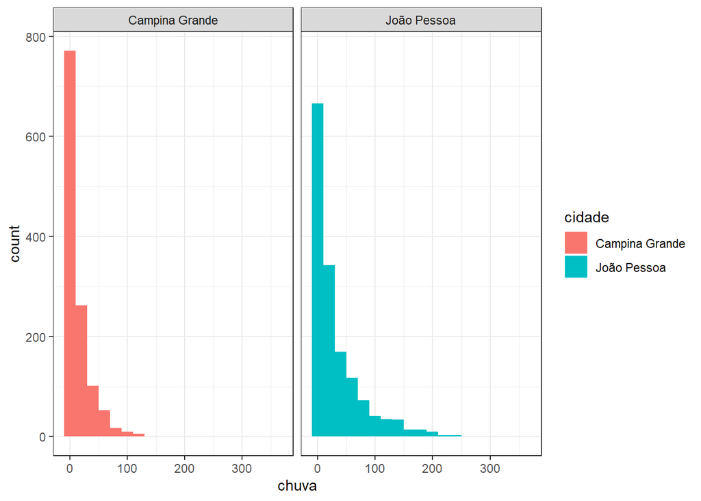

```r
climas_temp %>%
    ggplot(mapping = aes(x = chuva)) +
    facet_wrap(~cidade, ncol=2)+
    geom_histogram(binwidth = 20, aes(fill=cidade))
```

### Q4: O volume de chuvas varia mais ou menos que a temperatura das cidades?

1. A variabilidade do volume de chuvas possui comportamento atípico, com Q1 e Q2 dos boxplots com valores muito próximos de zero, além de apresentar muitos outliers. É uma característica própria do dado observado, haja vista que chove muito pouco (ou não chove) todas as semanas em ambas as cidades.
2. A variação das distribuições ocorre de forma inversa de acordo com os atributos observados em cada cidade, como observado nos gráficos abaixo. Enquanto a variação de chuva é muito maior em João Pessoa do que em Campina Grande, a temperatura varia muito mais em Campina Grande.

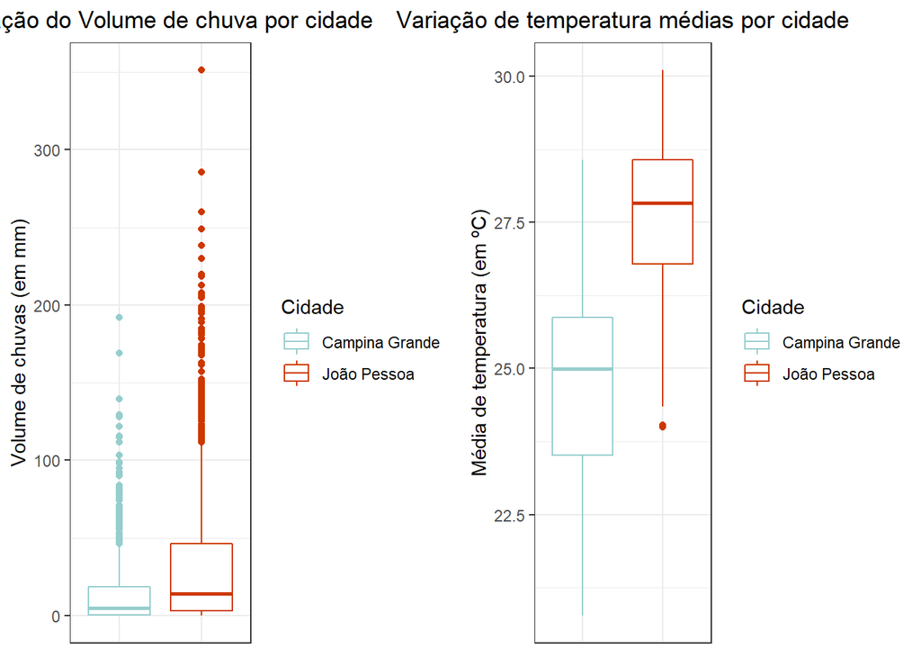

```r
g1 <- climas_temp %>%
    ggplot(aes( color = cidade)) +
    geom_boxplot(aes(x = cidade, y = chuva))+
    labs(y = "Volume de chuvas (em mm)", title = "Variação do Volume de chuva por cidade", color = "Cidade")+
    scale_color_manual(breaks = c("Campina Grande", "João Pessoa"), values=c("paleturquoise3","orangered3")) +
    theme(plot.title = element_text(hjust = 0.5),
          axis.title.x = element_blank(),
          axis.text.x=element_blank(),
          axis.ticks.x=element_blank())

g2 <- climas_temp %>%
    ggplot(aes( color = cidade)) +
    geom_boxplot(aes(x = cidade, y = tmedia))+
    labs(y = "Média de temperatura (em ºC)", title = "Variação de temperatura médias por cidade", color = "Cidade") +
    scale_color_manual(breaks = c("Campina Grande", "João Pessoa"), values=c("paleturquoise3","orangered3"))+
    theme(plot.title = element_text(hjust = 0.5),
          axis.title.x = element_blank(),
          axis.text.x=element_blank(),
          axis.ticks.x=element_blank())

grid.arrange(g1, g2, ncol = 2)
```

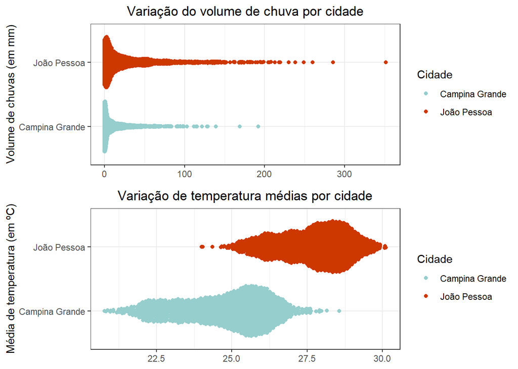

```r
f1 <- climas_temp %>%
    ggplot(aes(x = chuva, y = cidade, color = cidade)) +
    geom_quasirandom(groupOnX=FALSE) +
    labs(y = "Volume de chuvas (em mm)", title = "Variação do volume de chuva por cidade", color = "Cidade")+
    scale_color_manual(breaks = c("Campina Grande", "João Pessoa"), values=c("paleturquoise3","orangered3")) +
    theme(plot.title = element_text(hjust = 0.5), axis.title.x = element_blank())

f2 <- climas_temp %>%
    ggplot(aes(x = tmedia, y = cidade, color = cidade)) +
    geom_quasirandom(groupOnX=FALSE) +
    labs(y = "Média de temperatura (em ºC)", title = "Variação de temperatura médias por cidade", color = "Cidade") +
    scale_color_manual(breaks = c("Campina Grande", "João Pessoa"), values=c("paleturquoise3","orangered3"))+
    theme(plot.title = element_text(hjust = 0.5), axis.title.x = element_blank())

grid.arrange(f1, f2, nrow = 2)
```